# Hockey Match Report

Analyst’s Diary Match Report

# Great Britain vs Austria

**16 May 2026**  
IIHF World Championship 2026 – Group Stage

Great Britain (GB) 2:5 Austria (AUT)

Report generated from the match shot-location pipeline. Metrics marked as proxies are based on OCR-extracted shot coordinates and should be interpreted as transparent spatial indicators rather than official tracking data.

Prepared by Antonin Kremenak

# Executive summary

- Austria generated the higher official shots-on-goal volume.
- Austria produced the stronger location-based Shot Quality Index.
- Austria got more attempts from the inner-slot / high-danger area.
- Austria led in high-danger chances based on the distance-and-lane proxy.

Shots On Goal

AUT: 33 | GB: 20

Blocked Shots

AUT: 9 | GB: 16

Scoring Chances

AUT: 18 | GB: 10

# 1. Public layer: simple match metrics

These visuals are designed as a simple entry point for wider audiences: official shots on goal, blocked shots, shot quality proxies and basic chance creation.

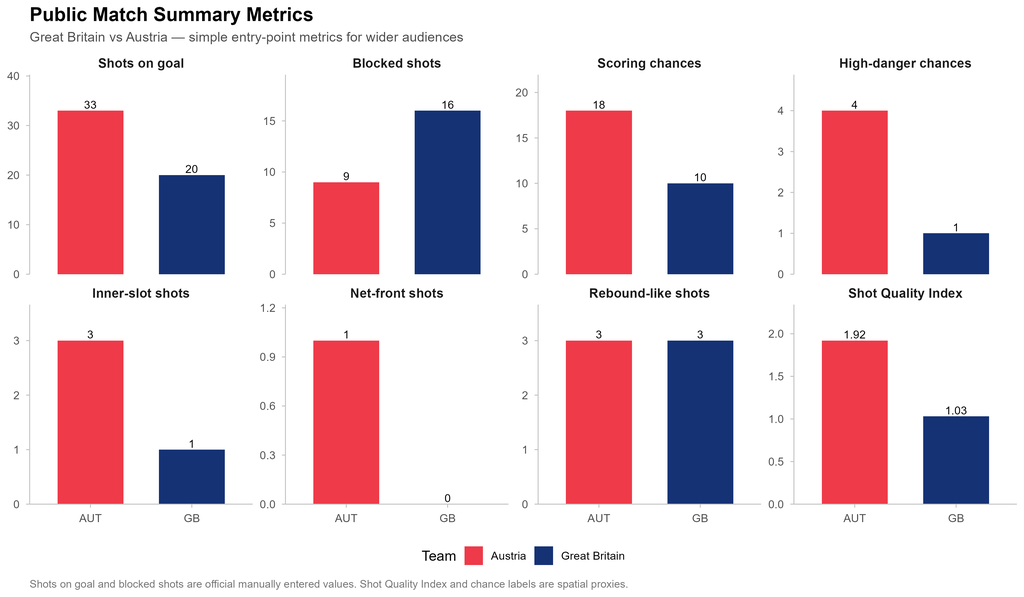

Key Metrics: Great Britain vs Austria

16 May 2026 — Shot Quality Index is a location-based proxy, not a trained xG model.

| Metric | GB | AUT |
| --- | --- | --- |
| OCR detected attempts | 21.00 | 29.00 |
| Corsi attempts | 21.00 | 29.00 |
| Fenwick attempts | 12.00 | 22.00 |
| Scoring chances | 10.00 | 18.00 |
| High-danger chances | 1.00 | 4.00 |
| Shot Quality Index | 1.03 | 1.92 |

# 2. Shot maps and spatial overview

Shot maps show where attempts came from, how dangerous they were spatially, and how shot locations changed across periods.

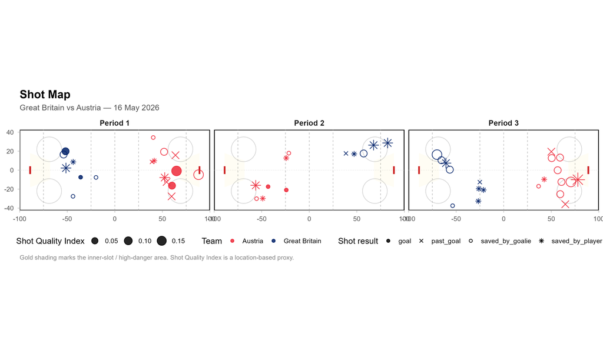

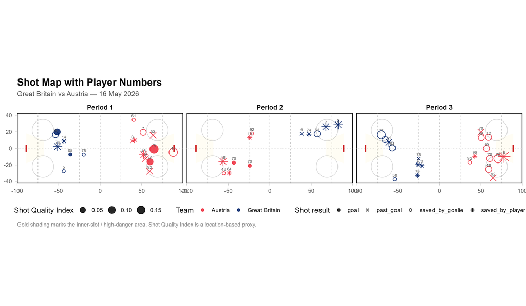

# 3. Shot quality and territorial battle

This section moves from simple shot counts to spatial pressure: location quality, offensive-zone density and period-by-period territorial advantage.

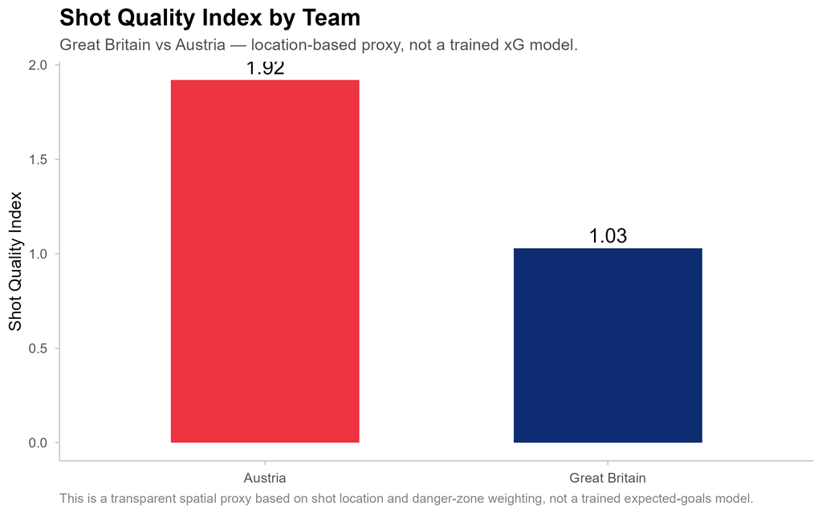

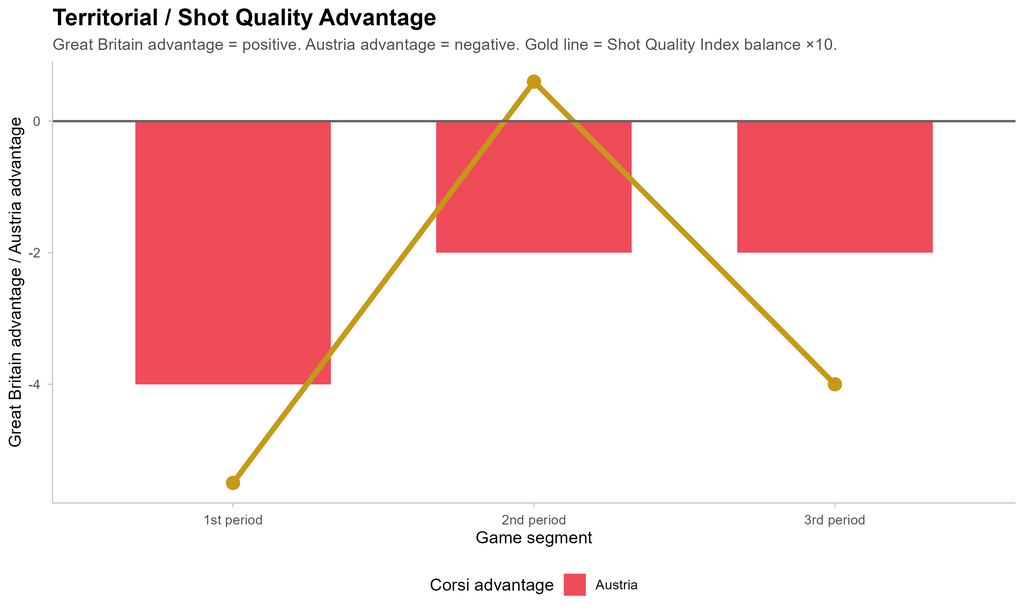

# 4. Offensive-zone density

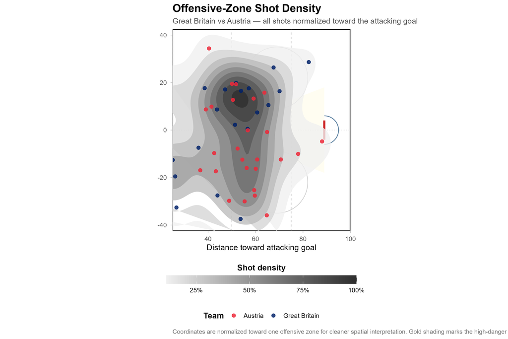

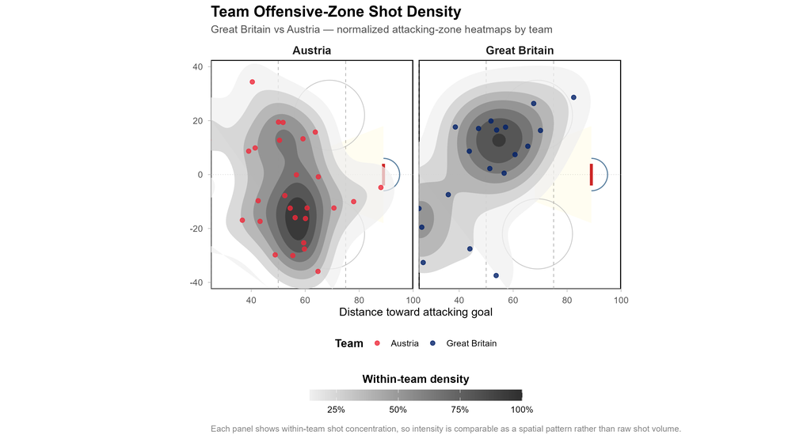

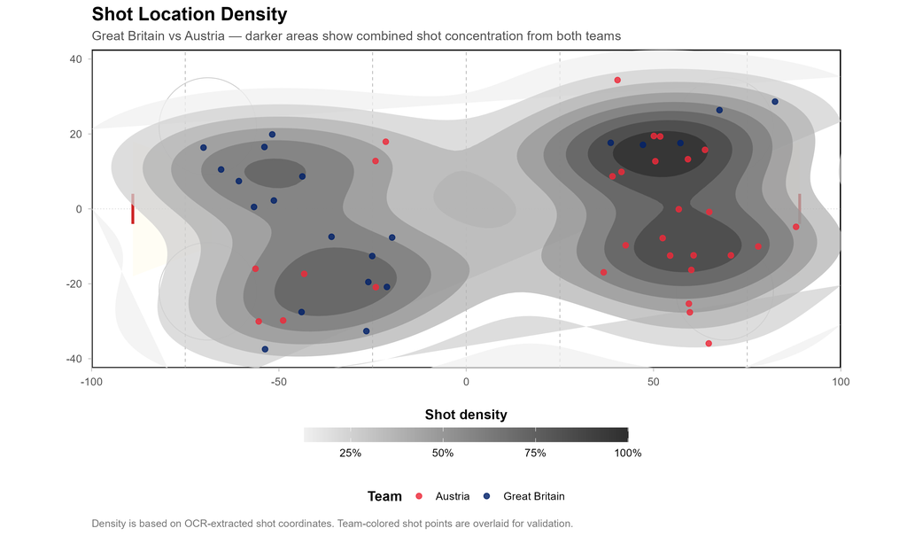

# 5. Advanced insider layer

The following metrics are proxy-based insider indicators built from the available shot-location sample. They are useful for storytelling, but they are not a substitute for full play-by-play or tracking data.

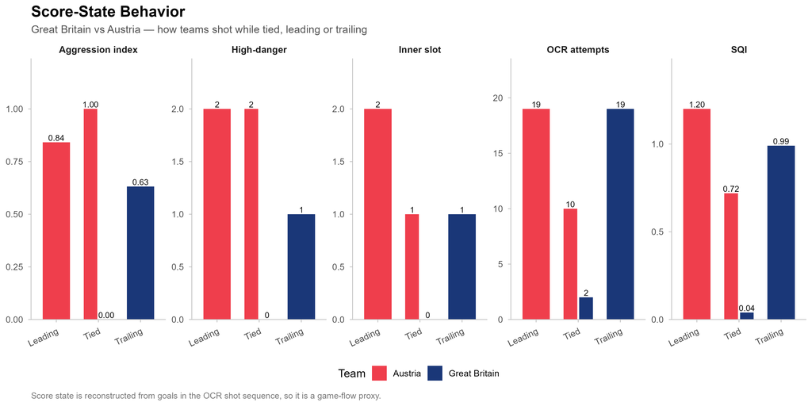

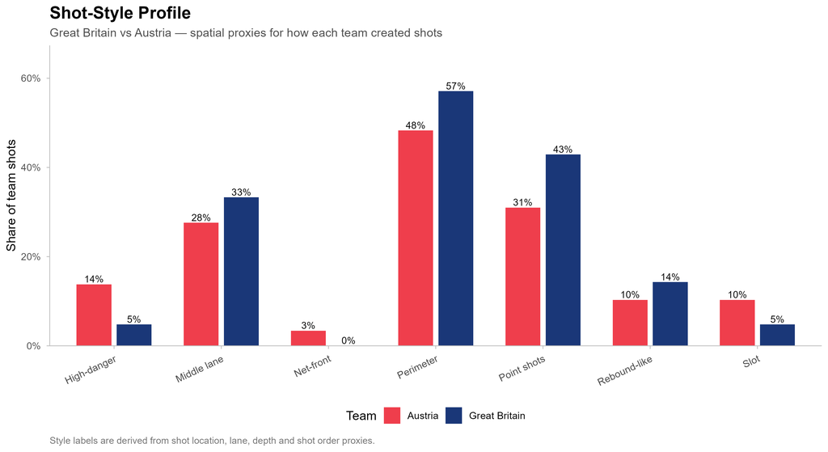

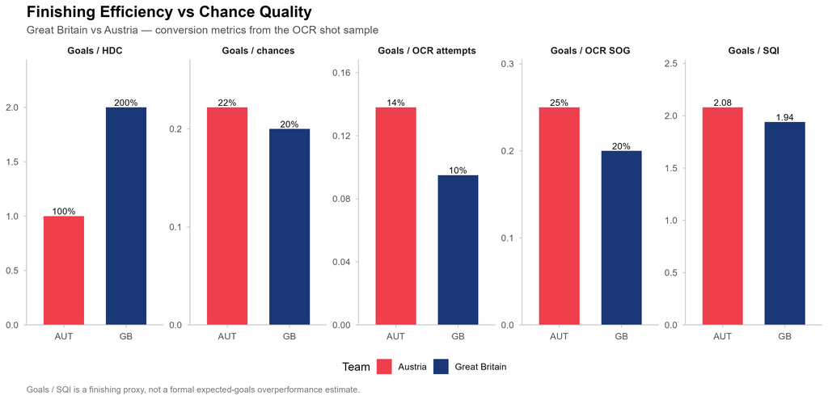

# 6. Momentum

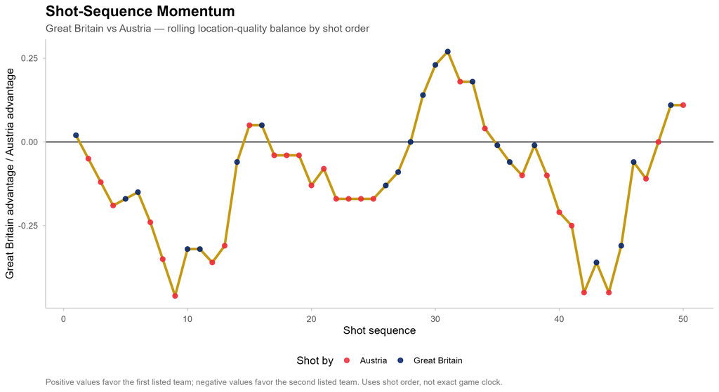

# 7. Player layer

**Player public leaders**

Top players from the OCR-extracted shot sample

| team | player_no | ocr_detected_attempts | ocr_shots_on_goal | scoring_chances | high_danger_chances | inner_slot_shots | net_front_shots | rebound_like_shots | shot_quality_index | avg_shot_distance | team_name |
| --- | --- | --- | --- | --- | --- | --- | --- | --- | --- | --- | --- |
| AUT | 70 | 6 | 5 | 4 | 2 | 1 | 0 | 1 | 0.54 | 39.6 | Austria |
| AUT | 48 | 5 | 3 | 4 | 1 | 1 | 1 | 0 | 0.41 | 32.5 | Austria |
| AUT | 8 | 1 | 0 | 1 | 1 | 1 | 0 | 0 | 0.18 | 14.9 | Austria |
| GB | 27 | 1 | 1 | 1 | 1 | 1 | 0 | 0 | 0.18 | 25.0 | Great Britain |
| AUT | 92 | 4 | 2 | 2 | 0 | 0 | 0 | 0 | 0.18 | 52.1 | Austria |
| GB | 61 | 2 | 1 | 2 | 0 | 0 | 0 | 0 | 0.14 | 32.8 | Great Britain |
| GB | 75 | 3 | 2 | 1 | 0 | 0 | 0 | 1 | 0.11 | 53.5 | Great Britain |
| AUT | 19 | 2 | 1 | 1 | 0 | 0 | 0 | 0 | 0.09 | 49.1 | Austria |
| AUT | 96 | 2 | 1 | 1 | 0 | 0 | 0 | 0 | 0.09 | 44.0 | Austria |
| GB | 3 | 2 | 0 | 1 | 0 | 0 | 0 | 1 | 0.09 | 50.2 | Great Britain |
| GB | 74 | 2 | 0 | 1 | 0 | 0 | 0 | 0 | 0.09 | 41.5 | Great Britain |
| GB | 9 | 2 | 1 | 1 | 0 | 0 | 0 | 0 | 0.09 | 46.1 | Great Britain |

#Source https://www.iihf.com/en/events/2026/wm/schedule